# Nanofish: Lipid peroxidation

# Set up environment

## Load libraries

## Load functions

## Load data

### Adjust classes and transformations

```
'data.frame':   467 obs. of  30 variables:
 $ StudyID             : Factor w/ 59 levels "2","3","4","5",..: 40 40 50 50 50 50 16 16 16 7 ...
 $ StudyCluster        : Factor w/ 34 levels "1","2","3","5",..: 4 4 5 5 5 5 4 4 4 18 ...
 $ Study               : Factor w/ 59 levels "Ašmonaitė et al., 2020",..: 1 1 2 2 2 2 3 3 3 4 ...
 $ Year                : int  2020 2020 2018 2018 2018 2018 2020 2020 2020 2019 ...
 $ EScluster           : Factor w/ 101 levels "1","2","3","4",..: 1 1 2 2 2 2 3 3 3 4 ...
 $ AdministrationRoute : Factor w/ 6 levels "Food","Injection",..: 1 1 4 4 4 4 1 1 1 4 ...
 $ Concentration_mg_L  : num  NA NA 0.26 0.69 0.26 0.69 NA NA NA 20 ...
 $ ParticleMaterial    : Factor w/ 7 levels "Aminoplast","LDPE",..: 6 3 1 1 1 1 3 3 3 6 ...
 $ Species             : Factor w/ 20 levels "Argyrosomus regius",..: 9 9 8 8 8 8 9 9 9 7 ...
 $ ParticleShape       : Factor w/ 4 levels "Irregular","Sphere",..: 2 2 2 2 2 2 2 2 2 2 ...
 $ Sex                 : Factor w/ 5 levels "F","F:M","FM",..: 5 5 5 5 5 5 5 5 5 NA ...
 $ DevelopmentalStage  : Factor w/ 5 levels "Embrio","Larva",..: 4 4 4 4 4 4 4 4 4 2 ...
 $ ExposureDurationCat : Factor w/ 3 levels "15 days +","5-15 days",..: 2 2 3 3 3 3 1 1 1 3 ...
 $ ExposureDurationDays: int  14 14 4 4 4 4 28 28 28 2 ...
```

[output cut: 16 more lines]

### Calculate Effect Size

```r
df_original <- metafor::escalc(measure = "SMD", n1i = n_treat, n2i = n_ctrl, m1i = mean_treat,
    m2i = mean_ctrl, sd1i = STD_treat, sd2i = STD_ctrl, data = df_original, vtype = "UB")
# write.csv(df_original,file = 'mvMetaAnalysis_SMDs.csv')
```

### Create variables

```r
outcome <- as.character(outcomeslist[[n_outcome]])

mRF <- list()  # random effects formula investigation models
mRE <- list()  # random effects multilevel models
mMR <- list()  # multilevel metaregression models

colormap <- c(Embrio = "khaki", Larva = "lightgreen", Juvenile = "lightskyblue",
    Adult = "salmon", Unclear = "plum", ExposureDurationDays = "cornflowerblue",
    ParticleSizeMean = "chartreuse4", Concentration_mg_L = "#fa0079ff", Aminoplast = "chocolate4",
    LDPE = "#2200faff", PE = "#0089faff", PET = "#00faedff", PLA = "#00fa29ff", PS = "#faf200ff",
    PVC = "#fa9a00ff", `Publication year` = "black", Variance = "navyblue")
```

### Select outcome

```
[1] "Lipid peroxidation"
```

|  | StudyID | StudyCluster | Study | Year | EScluster | AdministrationRoute | Concentration_mg_L | ParticleMaterial | Species | ParticleShape | Sex | DevelopmentalStage | ExposureDurationCat | ExposureDurationDays | ParticleSizeRange | ParticleSizeMean | ParticleSizeCat | Outcome | OutcomeCategory | Test_or_Assay | OutcomeVariable | Group | n_of_groups | n_ctrl | mean_ctrl | STD_ctrl | n_treat | mean_treat | STD_treat | … |
| --- | --- | --- | --- | --- | --- | --- | --- | --- | --- | --- | --- | --- | --- | --- | --- | --- | --- | --- | --- | --- | --- | --- | --- | --- | --- | --- | --- | --- | --- | --- |
| 5 | 105 | 6 | Barboza et al., 2018a | 2018 | 2 | Water: Semi-static system | 0.26 | Aminoplast | Dicentrarchus labrax | Sphere | Unclear | Adult | up to 96h | 4 | 1-5 | 3 | micro | Lipid peroxidation | Neurochemical outcomes | Oxidative Stress | Lipid peroxidation | MPs-L (0.26) | 2 | 9 | 172.907 | 65.753 | 9 | 219.178 | 102.283 | … |
| 6 | 105 | 6 | Barboza et al., 2018a | 2018 | 2 | Water: Semi-static system | 0.69 | Aminoplast | Dicentrarchus labrax | Sphere | Unclear | Adult | up to 96h | 4 | 1-5 | 3 | micro | Lipid peroxidation | Neurochemical outcomes | Oxidative Stress | Lipid peroxidation | MPs-H (0.69) | 2 | 9 | 172.907 | 65.753 | 9 | 379.909 | 233.79 | … |
| 17 | 53 | 10 | Campos et al., 2021 | 2021 | 5 | Water: Static system | 0.1 | LDPE | Argyrosomus regius | Irregular |  | Larva | up to 96h | 1 | 63-125 | 94 | micro | Lipid peroxidation | Neurochemical outcomes | Oxidative Stress | Lipid peroxidation | 0.1 (black circle) | 3 | 5 | 0.416 | 0.117 | 5 | 0.285 | 0.051 | … |
| 18 | 53 | 10 | Campos et al., 2021 | 2021 | 5 | Water: Static system | 1 | LDPE | Argyrosomus regius | Irregular |  | Larva | up to 96h | 1 | 63-125 | 94 | micro | Lipid peroxidation | Neurochemical outcomes | Oxidative Stress | Lipid peroxidation | 1 (black circle) | 3 | 5 | 0.416 | 0.117 | 5 | 0.329 | 0.066 | … |
| 19 | 53 | 10 | Campos et al., 2021 | 2021 | 5 | Water: Static system | 10 | LDPE | Argyrosomus regius | Irregular |  | Larva | up to 96h | 1 | 63-125 | 94 | micro | Lipid peroxidation | Neurochemical outcomes | Oxidative Stress | Lipid peroxidation | 10 (black circle) | 3 | 5 | 0.416 | 0.117 | 5 | 0.392 | 0.042 | … |
| 33 | 28 | 1 | Chagas et al., 2021 | 2021 | 9 | Water: Semi-static system | 2.5 | PLA | Danio rerio | Irregular | FM | Adult | 15 days + | 30 | 2.34 | 2.34 | micro | Lipid peroxidation | Neurochemical outcomes | Oxidative Stress | Lipid peroxidation | BP I (2,5 mg/L) | 2 | 10 | 2.298 | 0.051 | 10 | 2.736 | 0.043 | … |
| 34 | 28 | 1 | Chagas et al., 2021 | 2021 | 9 | Water: Semi-static system | 5 | PLA | Danio rerio | Irregular | FM | Adult | 15 days + | 30 | 2.34 | 2.34 | micro | Lipid peroxidation | Neurochemical outcomes | Oxidative Stress | Lipid peroxidation | BP II (5 mg/L) | 2 | 10 | 2.298 | 0.051 | 10 | 2.607 | 0.097 | … |
| 101 | 59 | 1 | Estrela et al., 2021 | 2021 | 38 | Water: Static system | 0.76 | PS | Ctenopharyngodon idella | Sphere | F:M | Juvenile | up to 96h | 3 | 0.02-0.026 | 0.023 | nano | Lipid peroxidation | Neurochemical outcomes | Oxidative Stress | Lipid peroxidation | PS NP | 1 | 16 | 0.397 | 0.12 | 16 | 0.654 | 0.231 | … |
| 118 | 117 | 1 | Guimarães et al., 2021 | 2021 | 43 | Water: Semi-static system | 4e-08 | PS | Ctenopharyngodon idella | Sphere |  | Unclear | 15 days + | 20 | 0.02-0.026 | 0.023 | nano | Lipid peroxidation | Neurochemical outcomes | Oxidative Stress | Lipid peroxidation | PS NP-I | 3 | 10 | 0.979 | 0.163 | 10 | 1.518 | 0.261 | … |
| 119 | 117 | 1 | Guimarães et al., 2021 | 2021 | 43 | Water: Semi-static system | 3.4e-05 | PS | Ctenopharyngodon idella | Sphere |  | Unclear | 15 days + | 20 | 0.02-0.026 | 0.023 | nano | Lipid peroxidation | Neurochemical outcomes | Oxidative Stress | Lipid peroxidation | PS NP-II | 3 | 10 | 0.979 | 0.163 | 10 | 1.242 | 0.071 | … |

[output cut: 38 more lines]

# Exploratory data analysis

## Funnel plot

> Before running any meta-analytic model, it is important to explore the meta-analytic dataset to search for potential outliers that could represent data extraction errors. (Nakagawa et al. 2022)

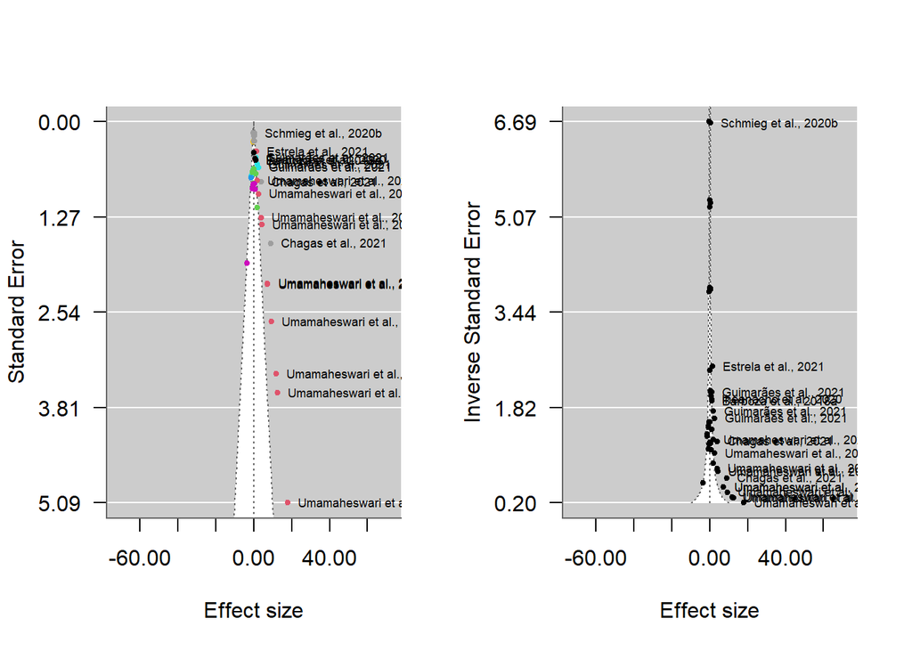

## Alluvial plot

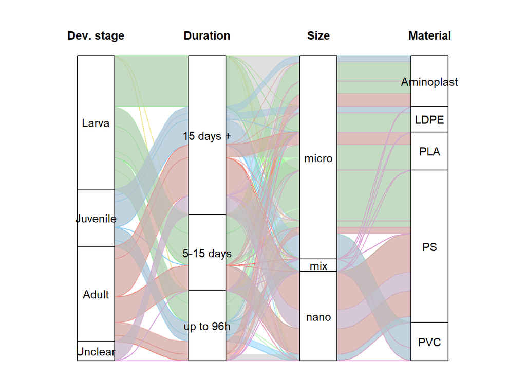

# Multilevel meta-analytic model

## Random effects formula desing

```
[1] "Considering number of studies: 16, number of ES clusters: 25 and number of independent observations of ES: 48, the random effects formula for Lipid peroxidation is: ~1 | Study/EScluster/ESid"
```

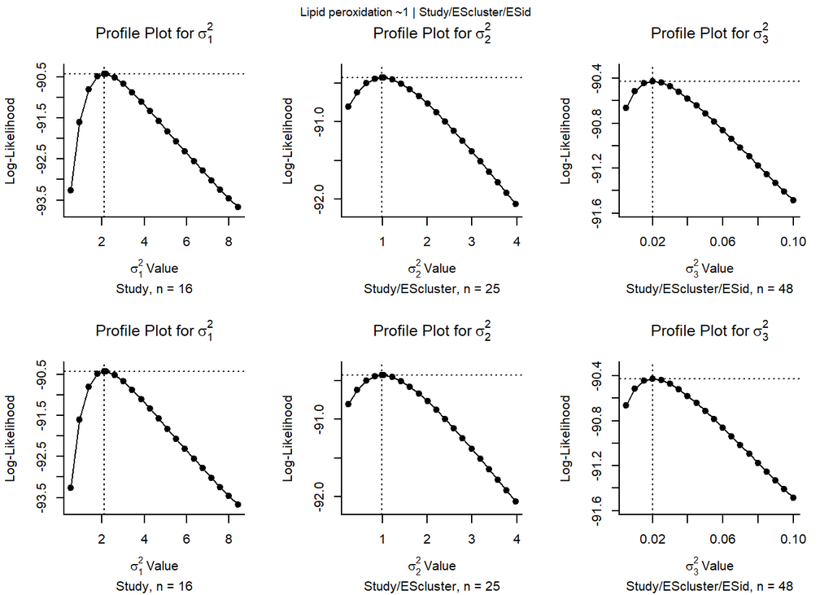

> A profile likelihood plot should show a single peak at the corresponding ML/REML estimate. If `refline=TRUE` (the default), the value of the parameter estimate is indicated by a dotted vertical line and its log-likelihood value by a dotted horizontal line. Hence, the intersection of these two lines should correspond to the peak (assuming that the model was fitted with ML/REML estimation).

> When profiling a variance component (or some other parameter that cannot be negative), the peak may be at zero (if this corresponds to the ML/REML estimate of the parameter). In this case, the profiled log-likelihood should be a monotonically decreasing function of the parameter. Similarly, when profiling a correlation component, the peak may be at -1 or +1.

> If the profiled log-likelihood has multiple peaks, this indicates that the likelihood surface is not unimodal. In such cases, the ML/REML estimate may correspond to a local optimum (when the intersection of the two dotted lines is not at the highest peak).

> If the profile is flat (over the entire parameter space or large portions of it), then this suggests that at least some of the parameters of the model are not identifiable (and the parameter estimates obtained are to some extent arbitrary). See Raue et al. (2009) for some further discussion of parameter identifiability and the use of profile likelihoods to check for this.

> The function checks whether any profiled log-likelihood value is actually larger than the log-likelihood of the fitted model (using a numerical tolerance of `lltol`). If so, a warning is issued as this might indicate that the optimizer did not identify the actual ML/REML estimate of the parameter profiled.[Viechtbauer (2022)](Viechtbauer 2010)

## Additional random effects factors

Study cluster, particle material and species as random effects term can further improve results?

|  | Nested | +StudyCluster | +Particle Material | +Species |
| --- | --- | --- | --- | --- |
| logLik: | -90.42551637568123 | -89.21861798790304 | -90.42551638375176 | -90.425516384275 |
| deviance: | 129.9283923923721 | 127.5145956168157 | 129.9283924085132 | 129.9283924095596 |
| AIC: | 188.8510327513625 | 188.4372359758061 | 190.8510327675035 | 190.85103276855 |
| BIC: | 196.335836794994 | 197.7932410303455 | 200.207037822043 | 200.2070378230895 |
| AICc: | 189.781265309502 | 189.8658074043775 | 192.2796041960749 | 192.2796041971214 |

|  | Comparison | LRT | p_value |
| --- | --- | --- | --- |
| 1 | +Study Cluster | 2.41 | 0.12 |
| 2 | +Particle Material | 0 | 1 |
| 3 | +Species | 0 | 1 |

Additional term to insert: none

## Main result: Multilevel model with $\rho = 0.5$ and robust variance estimate

```r
# Assumed correlation of rho = 0.5, except if there is only one ES by Study (no
# correlation)
if (nES == nSt) {
    VCVrho <- 0
    VCV <- df$vi
} else {
    VCVrho <- 0.5
    VCV <- vcalc(vi, cluster = interaction(df$EScluster, df$Study), obs = ESid, data = df,
        rho = VCVrho)
}

mname1 <- "ML"
mname2 <- paste0(mname1, "_RobVar")

mRE[[mname1]] <- rma.mv(yi, VCV, random = RE_formula, data = df, slab = Study, method = "REML",
    test = "t", dfs = "contain", level = 95)
mRE[[mname1]] <- additional_results(mRE[[mname1]])

mRE[[mname2]] <- robust(mRE[[mname1]], cluster = df$Study, clubSandwich = TRUE)

mRE[[mname2]] <- additional_results(mRE[[mname2]])

I2_ML_RobVar <- i2_ml(mRE[[mname2]])
# I2_ML_RobVar <- i2_ml(mRE[[mname2]], boot = 1000)

extract_report(mRE[[mname2]], outcome, RE_formula)
```

#### Diagnostics plots and results

```
Multivariate Meta-Analysis Model (k = 48; method: REML)

  logLik  Deviance       AIC       BIC      AICc
-83.8645  167.7289  175.7289  183.1295  176.6813

Variance Components:

            estim    sqrt  nlvls  fixed                factor
sigma^2.1  1.4406  1.2003     16     no                 Study
sigma^2.2  0.0000  0.0000     25     no       Study/EScluster
sigma^2.3  0.0401  0.2002     48     no  Study/EScluster/ESid

Test for Heterogeneity:
Q(df = 47) = 175.6176, p-val < .0001

Number of estimates:   48
Number of clusters:    16
Estimates per cluster: 0-10 (mean: 0.81, median: 0)

Model Results:

estimate      se¹    tval¹    df¹    pval¹    ci.lb¹   ci.ub¹
  0.6327  0.3331   1.8996   14.8   0.0771   -0.0781   1.3435   .

---
Signif. codes:  0 '***' 0.001 '**' 0.01 '*' 0.05 '.' 0.1 ' ' 1

1) results based on cluster-robust inference (var-cov estimator: CR2,
   approx t-test and confidence interval, df: Satterthwaite approx)
```

```
               I2_Total                I2_Study      I2_Study/EScluster
           9.019822e+01            8.775570e+01            4.773860e-08
I2_Study/EScluster/ESid
           2.442521e+00
```

```
$results
        % of total variance    I2
Level 1        9.801780e+00   ---
Level 2        2.442521e+00  2.44
Level 3        4.773860e-08     0
Level 4        8.775570e+01 87.76

$totalI2
[1] 90.19822

$plot
```

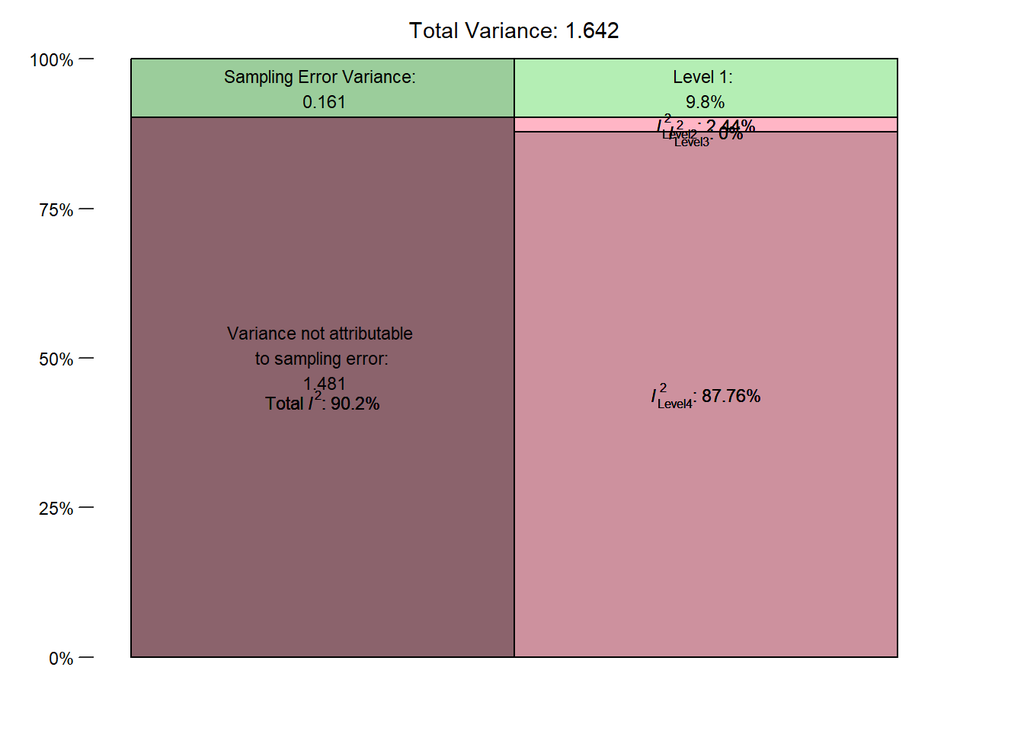

```
attr(,"class")
[1] "mlm.variance.distribution" "list"
```

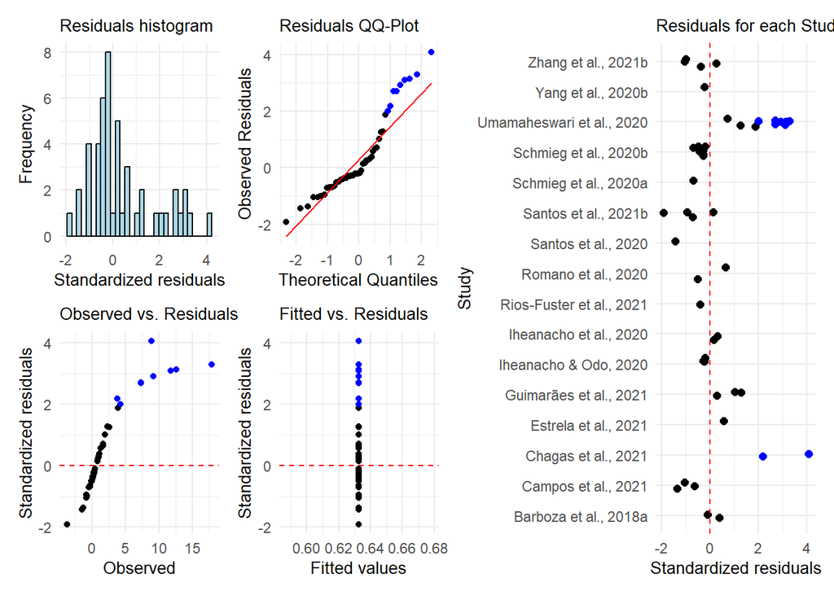

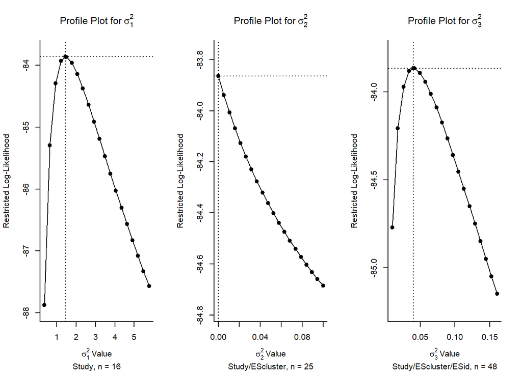

The meta-analysis comprised 48 comparisons from 25 control group clusters of 16 independent studies, so the random formula for Lipid peroxidation was ~1 | Study/EScluster/ESid.

No difference between treatment and control groups (ES = 0.6327077 ± 0.3330739, CI95% = -0.0780507 to 1.343466, predicted interval -2.059501 to 3.3249164), with high heterogeneity (i² = 90.2, Q = 175.617619, p < 0.001 ) and variance explained by each component of $\sigma^2_{Study} = 1.44$, $\sigma^2_{EScluster} = 0.00$, $\sigma^2_{ESid} = 0.04$.

# Publication bias

> **Small-study effect:** when small studies (with small sample sizes) tend to report large effect sizes. (Yang et al. 2023)

> While the PET method works best when the true effect captured by β0β0 is **zero**, PEESE shows a better performance when the true effect is **not** zero. Stanley and Doucouliagos ([2014](https://bookdown.org/MathiasHarrer/Doing_Meta_Analysis_in_R/references.html#ref-stanley2014meta)) therefore proposed to combine both methods, in order to balance out their individual strengths. The resulting approach is the PET-PEESE method. PET-PEESE uses the intercept β0 of either PET or PEESE as the estimate of the corrected true effect.

> Whether PET or PEESE is used depends on the size of the intercept calculated by the PET method. When β0PET is significantly larger than zero in a one-sided test with α = 0.05, we use the intercept of PEESE as the true effect size estimate. If PET’s intercept is not significantly larger than zero, we remain with the PET estimate.

> In most implementations of regression models in *R*, it is conventional to test the significance of coefficients using a two-sided test (i.e. we test if a ββ weight significantly differs from zero, no matter the direction). To assume a one-sided test with α = 0.05, we already regard the intercept as significant when p < 0.1, and when the estimate of β0 is larger than zero<sup>38</sup>. (Harrer et al., n.d.)

> **Time-lag bias:** when statistically significant (“positive” results) tend to be published earlier than those with statistically non-significant findings (“negative” results), leading to a decline in reported effect sizes over time (i.e., a decline effect). (Yang et al. 2023)

> Given that high heterogeneity may invalidate publication bias test, it is best to account for the potential heterogeneity when testing publication bias. (Yang et al. 2023)

> PET-PEESE performs poorly in research areas where there are only a few studies, all studies use small samples, and where there is very high heterogeneity of results from study to study. Nonetheless, the statistical properties of conventional meta-analysis approaches are much worse than PET-PEESE under these same conditions.(Stanley 2017)

So, **better use meta-regression dataset**, but requires larger dataset to avoid possible convergence issues.

#### Plots

```
[1] "PEESE"
```

```
Multivariate Meta-Analysis Model (k = 48; method: REML)

  logLik  Deviance       AIC       BIC      AICc
-65.5006  131.0012  143.0012  153.8411  145.2117

Variance Components:

            estim    sqrt  nlvls  fixed                factor
sigma^2.1  1.1801  1.0863     16     no                 Study
sigma^2.2  0.0000  0.0000     25     no       Study/EScluster
sigma^2.3  0.0318  0.1783     48     no  Study/EScluster/ESid

Test for Residual Heterogeneity:
QE(df = 45) = 126.1839, p-val < .0001

Number of estimates:   48
Number of clusters:    16
Estimates per cluster: 0-10 (mean: 0.81, median: 0)

Test of Moderators (coefficients 2:3):¹
F(df1 = 2, df2 = 1.43) = 15.5542, p-val = 0.1075

Model Results:

          estimate      se¹    tval¹    df¹    pval¹    ci.lb¹   ci.ub¹
intrcpt     0.2576  0.2510   1.0262   7.27   0.3377   -0.3315   0.8467
vi          0.7734  0.1287   6.0086   1.18   0.0795   -0.3804   1.9273   .
pub_year    0.0148  0.3271   0.0454   2.68   0.9670   -1.1001   1.1297

---
Signif. codes:  0 '***' 0.001 '**' 0.01 '*' 0.05 '.' 0.1 ' ' 1

1) results based on cluster-robust inference (var-cov estimator: CR2,
   approx t/F-tests and confidence intervals, df: Satterthwaite approx)
```

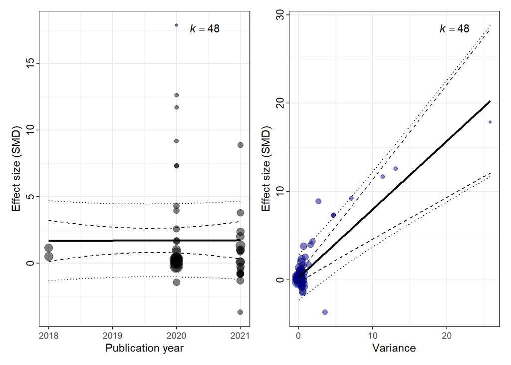

**Small-study effect** The regression slope of the extended Egger’s regression is $\sqrt{SMDSE} = 0.7734206$ is it statistically different from zero?`

If p<0.050: Smaller studies (with larger sampling error) have larger effect sizes –> small-study effect exists in this dataset. Data is assymmetrically distributed in the funnel plot.

If p>=0.050 no small-study effect exists in this dataset. Smaller studies (with larger sampling error) do not have larger effect sizes –> no small-study effect exists in this dataset. Data is symmetrically distributed in the funnel plot.

If p<0.050: studies with statistically significant findings tend to be published earlier than these with “negative” results, i.e. time-lag bias exists in this dataset

If p>=0.050: studies with statistically significant findings **do not** tend to be published earlier than these with “negative” results, i.e. no time-lag bias exists in this dataset

### Sensitivity analysis: publication bias with adapted SE

> Egger’s regression and its variants suffer from low power and poor performance when there are fewer than 20 effect sizes, or when the overall effect is large. (Nakagawa et al. 2022)

> Instead of the sample size (n1 + n2), however, for a meta-analysis of SMD or lnRR, we propose using the ‘effective sample size’ because it accounts for unbalanced sampling (cf. Stanley, 2005).(Nakagawa et al. 2022)

```r
if (mRE[[bias]]$pval[2] < 0.05) {

    # calculate modified SE based on effective sample size
    df$ess_vi <- with(df, sqrt((n_treat + n_ctrl)/(n_treat * n_ctrl)))
    df$ess_SE <- sqrt(df$ess_vi)  ## sampling error for ES

    # PET + year
    bias2 <- "PET sensitivity"
    mRE[[bias2]] <- rma.mv(yi, VCV, random = RE_formula, mods = ~ess_SE + pub_year,
        data = df, slab = Study, method = "REML", test = "t", dfs = "contain", level = 95)
    mRE[[bias2]] <- robust(mRE[[bias2]], cluster = df$Study, clubSandwich = TRUE)
    mRE[[bias2]] <- additional_results(mRE[[bias2]])

    # PEESE + year
    if (mRE[[bias2]]$pval[2] < 0.1) {
        mname <- "PEESE sensitivity"
        mRE[[mname]] <- rma.mv(yi, VCV, random = RE_formula, mods = ~ess_vi + pub_year,
            data = df, slab = Study, method = "REML", test = "t", dfs = "contain",
            level = 95)
        mRE[[mname]] <- robust(mRE[[mname]], cluster = df$Study, clubSandwich = TRUE)
        mRE[[mname]] <- additional_results(mRE[[mname]])
        bias2 <- mname
    }
    print(bias2)
    summary(mRE[[bias2]])
}
```

If the results are the same, indicates the robustness of the small-study test.

#### Plots

# Sensitivity

## Rho range

```r
if (VCVrho != 0) {

    rho_range <- c(0, 0.25, 0.75, 0.9)  # assume a range values of rho

    for (j in 1:length(rho_range)) {

        mname <- paste("rho", rho_range[j], sep = "_")

        VCV2 <- vcalc(vi, cluster = interaction(df$EScluster, df$Study), obs = ESid,
            data = df, rho = rho_range[j])

        mRE[[mname]] <- rma.mv(yi, VCV2, random = RE_formula, data = df, slab = Study,
            method = "REML", test = "t", dfs = "contain", level = 95)
        mRE[[mname]] <- robust(mRE[[mname]], cluster = df$Study, clubSandwich = TRUE)
        mRE[[mname]] <- additional_results(mRE[[mname]])
    }
}
```

## Leave one out + Rho range

```r
if (VCVrho != 0) {
    rho_range <- c(0.25, 0.5, 0.75, 0.9)
} else {
    rho_range <- 0
}

for (i in sort(unique(df$Study))) {

    df_temp <- df[df$Study != i, ]

    for (j in 1:length(rho_range)) {

        mname <- paste("rho", rho_range[j], "l1o", i, sep = "_")
        print(mname)
        VCV2 <- vcalc(vi, cluster = interaction(df_temp$EScluster, df_temp$Study),
            obs = ESid, data = df_temp, rho = rho_range[j])

        mRE[[mname]] <- rma.mv(yi, VCV2, random = RE_formula, data = df_temp, slab = Study,
            method = "REML", test = "t", dfs = "contain", level = 95)
        mRE[[mname]] <- robust(mRE[[mname]], cluster = df_temp$Study, clubSandwich = TRUE)
        mRE[[mname]] <- additional_results(mRE[[mname]])
    }
}
```

```
[1] "rho_0.25_l1o_Barboza et al., 2018a"
[1] "rho_0.5_l1o_Barboza et al., 2018a"
[1] "rho_0.75_l1o_Barboza et al., 2018a"
[1] "rho_0.9_l1o_Barboza et al., 2018a"
[1] "rho_0.25_l1o_Campos et al., 2021"
[1] "rho_0.5_l1o_Campos et al., 2021"
[1] "rho_0.75_l1o_Campos et al., 2021"
[1] "rho_0.9_l1o_Campos et al., 2021"
[1] "rho_0.25_l1o_Chagas et al., 2021"
[1] "rho_0.5_l1o_Chagas et al., 2021"
[1] "rho_0.75_l1o_Chagas et al., 2021"
[1] "rho_0.9_l1o_Chagas et al., 2021"
[1] "rho_0.25_l1o_Estrela et al., 2021"
[1] "rho_0.5_l1o_Estrela et al., 2021"
[1] "rho_0.75_l1o_Estrela et al., 2021"
```

[output cut: 49 more lines]

# Tables

|  | n studies | n ES clusters | n ES | overall effect | standard error | p-value | Lower CI | Upper CI | Lower PI | Upper PI | Q | Q p-value | $I^2$$_{total}$ | $I^2$$_{Study}$ | $I^2$$_{EScluster}$ | $I^2$$_{ES}$ | $\sigma^2$$_{Study}$ | $\sigma^2$$_{EScluster}$ | $\sigma^2$$_{ES}$ |
| --- | --- | --- | --- | --- | --- | --- | --- | --- | --- | --- | --- | --- | --- | --- | --- | --- | --- | --- | --- |
| ML | 16 | 25 | 48 | 0.63 | 0.3 | 0.0743 | -0.07 | 1.34 | -2.05 | 3.32 | 175.62 | 0 | 90.20 | 87.76 | 0.00 | 2.44 | 1.44 | 0.00 | 0.04 |
| ML_RobVar | 16 | 25 | 48 | 0.63 | 0.3 | 0.0771 | -0.08 | 1.34 | -2.06 | 3.32 | 175.62 | 0 | 90.20 | 87.76 | 0.00 | 2.44 | 1.44 | 0.00 | 0.04 |
| PET | 16 | 25 | 48 | -1.28 | 0.6 | 0.0651 | -2.66 | 0.11 | -4.55 | 1.99 | 131.23 | 0 | 90.61 | 89.07 | 0.00 | 1.53 | 1.53 | 0.00 | 0.03 |
| PEESE | 16 | 25 | 48 | 0.26 | 0.3 | 0.3377 | -0.33 | 0.85 | -2.39 | 2.91 | 126.18 | 0 | 88.28 | 85.96 | 0.00 | 2.32 | 1.18 | 0.00 | 0.03 |
| rho_0 | 16 | 25 | 48 | 0.84 | 0.5 | 0.0979 | -0.18 | 1.86 | -3.28 | 4.96 | 224.08 | 0 | 95.61 | 63.59 | 31.46 | 0.55 | 2.33 | 1.15 | 0.02 |
| rho_0.25 | 16 | 25 | 48 | 0.69 | 0.4 | 0.0758 | -0.08 | 1.45 | -2.27 | 3.64 | 189.15 | 0 | 91.74 | 90.51 | 0.00 | 1.23 | 1.76 | 0.00 | 0.02 |
| rho_0.75 | 16 | 25 | 48 | 0.59 | 0.3 | 0.0790 | -0.08 | 1.25 | -1.92 | 3.09 | 193.67 | 0 | 88.83 | 78.72 | 0.00 | 10.11 | 1.13 | 0.00 | 0.15 |
| rho_0.9 | 16 | 25 | 48 | 0.56 | 0.3 | 0.0791 | -0.07 | 1.20 | -1.86 | 2.98 | 291.89 | 0 | 88.09 | 68.61 | 0.00 | 19.48 | 0.93 | 0.00 | 0.26 |
| rho_0.25_l1o_Barboza et al., 2018a | 15 | 24 | 46 | 0.68 | 0.4 | 0.1017 | -0.15 | 1.51 | -2.44 | 3.80 | 186.24 | 0 | 92.51 | 91.36 | 0.00 | 1.15 | 1.93 | 0.00 | 0.02 |
| rho_0.5_l1o_Barboza et al., 2018a | 15 | 24 | 46 | 0.62 | 0.4 | 0.1054 | -0.15 | 1.40 | -2.22 | 3.47 | 172.51 | 0 | 91.12 | 88.89 | 0.00 | 2.22 | 1.59 | 0.00 | 0.04 |
| rho_0.75_l1o_Barboza et al., 2018a | 15 | 24 | 46 | 0.57 | 0.3 | 0.1100 | -0.15 | 1.30 | -2.08 | 3.23 | 189.30 | 0 | 89.92 | 80.36 | 0.00 | 9.56 | 1.26 | 0.00 | 0.15 |
| rho_0.9_l1o_Barboza et al., 2018a | 15 | 24 | 46 | 0.55 | 0.3 | 0.1114 | -0.14 | 1.24 | -2.02 | 3.12 | 283.26 | 0 | 89.32 | 70.75 | 0.00 | 18.56 | 1.05 | 0.00 | 0.28 |
| rho_0.25_l1o_Campos et al., 2021 | 15 | 24 | 45 | 0.78 | 0.4 | 0.0540 | -0.02 | 1.58 | -2.19 | 3.76 | 183.14 | 0 | 92.03 | 90.76 | 0.00 | 1.28 | 1.76 | 0.00 | 0.02 |
| rho_0.5_l1o_Campos et al., 2021 | 15 | 24 | 45 | 0.72 | 0.3 | 0.0552 | -0.02 | 1.46 | -1.99 | 3.43 | 170.26 | 0 | 90.55 | 88.06 | 0.00 | 2.49 | 1.44 | 0.00 | 0.04 |
| rho_0.75_l1o_Campos et al., 2021 | 15 | 24 | 45 | 0.67 | 0.3 | 0.0561 | -0.02 | 1.36 | -1.86 | 3.20 | 187.27 | 0 | 89.25 | 78.84 | 0.00 | 10.41 | 1.13 | 0.00 | 0.15 |
| rho_0.9_l1o_Campos et al., 2021 | 15 | 24 | 45 | 0.65 | 0.3 | 0.0549 | -0.02 | 1.31 | -1.80 | 3.10 | 280.33 | 0 | 88.62 | 68.31 | 0.00 | 20.31 | 0.93 | 0.00 | 0.28 |
| rho_0.25_l1o_Chagas et al., 2021 | 15 | 24 | 46 | 0.48 | 0.3 | 0.1338 | -0.17 | 1.12 | -1.88 | 2.83 | 150.62 | 0 | 87.75 | 86.01 | 0.00 | 1.74 | 1.09 | 0.00 | 0.02 |
| rho_0.5_l1o_Chagas et al., 2021 | 15 | 24 | 46 | 0.46 | 0.3 | 0.1384 | -0.17 | 1.09 | -1.80 | 2.72 | 143.04 | 0 | 86.77 | 83.77 | 0.00 | 3.01 | 0.98 | 0.00 | 0.04 |
| rho_0.75_l1o_Chagas et al., 2021 | 15 | 24 | 46 | 0.44 | 0.3 | 0.1436 | -0.17 | 1.06 | -1.77 | 2.65 | 164.68 | 0 | 86.29 | 76.37 | 0.00 | 9.92 | 0.86 | 0.00 | 0.11 |
| rho_0.9_l1o_Chagas et al., 2021 | 15 | 24 | 46 | 0.43 | 0.3 | 0.1436 | -0.17 | 1.03 | -1.74 | 2.60 | 262.54 | 0 | 85.86 | 67.35 | 0.00 | 18.51 | 0.74 | 0.00 | 0.20 |
| rho_0.25_l1o_Estrela et al., 2021 | 15 | 24 | 47 | 0.64 | 0.4 | 0.1175 | -0.18 | 1.46 | -2.44 | 3.72 | 181.43 | 0 | 92.23 | 91.07 | 0.00 | 1.17 | 1.89 | 0.00 | 0.02 |
| rho_0.5_l1o_Estrela et al., 2021 | 15 | 24 | 47 | 0.58 | 0.4 | 0.1233 | -0.18 | 1.34 | -2.22 | 3.39 | 167.71 | 0 | 90.73 | 88.41 | 0.00 | 2.32 | 1.54 | 0.00 | 0.04 |
| rho_0.75_l1o_Estrela et al., 2021 | 15 | 24 | 47 | 0.53 | 0.3 | 0.1285 | -0.18 | 1.24 | -2.06 | 3.13 | 185.42 | 0 | 89.35 | 79.64 | 0.00 | 9.71 | 1.21 | 0.00 | 0.15 |
| rho_0.9_l1o_Estrela et al., 2021 | 15 | 24 | 47 | 0.51 | 0.3 | 0.1292 | -0.17 | 1.18 | -1.99 | 3.00 | 282.87 | 0 | 88.56 | 69.77 | 0.00 | 18.78 | 0.98 | 0.00 | 0.26 |
| rho_0.25_l1o_Guimarães et al., 2021 | 15 | 24 | 45 | 0.62 | 0.4 | 0.1252 | -0.20 | 1.43 | -2.42 | 3.66 | 171.82 | 0 | 92.27 | 91.23 | 0.00 | 1.04 | 1.85 | 0.00 | 0.02 |
| rho_0.5_l1o_Guimarães et al., 2021 | 15 | 24 | 45 | 0.57 | 0.3 | 0.1288 | -0.19 | 1.32 | -2.19 | 3.32 | 160.49 | 0 | 90.70 | 88.90 | 0.00 | 1.80 | 1.49 | 0.00 | 0.03 |
| rho_0.75_l1o_Guimarães et al., 2021 | 15 | 24 | 45 | 0.50 | 0.3 | 0.1376 | -0.18 | 1.18 | -1.96 | 2.96 | 176.54 | 0 | 88.57 | 81.29 | 0.00 | 7.27 | 1.11 | 0.00 | 0.10 |
| rho_0.9_l1o_Guimarães et al., 2021 | 15 | 24 | 45 | 0.47 | 0.3 | 0.1410 | -0.18 | 1.13 | -1.91 | 2.86 | 263.52 | 0 | 87.92 | 69.68 | 0.00 | 18.24 | 0.90 | 0.00 | 0.24 |
| rho_0.25_l1o_Iheanacho & Odo, 2020 | 15 | 24 | 45 | 0.71 | 0.4 | 0.0868 | -0.12 | 1.55 | -2.40 | 3.83 | 189.09 | 0 | 92.53 | 91.19 | 0.00 | 1.34 | 1.93 | 0.00 | 0.03 |
| rho_0.5_l1o_Iheanacho & Odo, 2020 | 15 | 24 | 45 | 0.66 | 0.4 | 0.0890 | -0.12 | 1.44 | -2.21 | 3.53 | 175.54 | 0 | 91.26 | 88.34 | 0.00 | 2.92 | 1.60 | 0.00 | 0.05 |
| rho_0.75_l1o_Iheanacho & Odo, 2020 | 15 | 24 | 45 | 0.63 | 0.3 | 0.0909 | -0.11 | 1.37 | -2.11 | 3.37 | 193.52 | 0 | 90.49 | 78.95 | 0.00 | 11.54 | 1.31 | 0.00 | 0.19 |
| rho_0.9_l1o_Iheanacho & Odo, 2020 | 15 | 24 | 45 | 0.60 | 0.3 | 0.0915 | -0.11 | 1.31 | -2.05 | 3.26 | 291.52 | 0 | 89.94 | 69.90 | 0.00 | 20.04 | 1.10 | 0.00 | 0.32 |
| rho_0.25_l1o_Iheanacho et al., 2020 | 15 | 24 | 46 | 0.67 | 0.4 | 0.1059 | -0.16 | 1.50 | -2.45 | 3.79 | 186.13 | 0 | 92.50 | 91.28 | 0.00 | 1.22 | 1.93 | 0.00 | 0.03 |
| rho_0.5_l1o_Iheanacho et al., 2020 | 15 | 24 | 46 | 0.61 | 0.4 | 0.1100 | -0.16 | 1.39 | -2.23 | 3.46 | 172.98 | 0 | 91.14 | 88.63 | 0.00 | 2.51 | 1.59 | 0.00 | 0.04 |
| rho_0.75_l1o_Iheanacho et al., 2020 | 15 | 24 | 46 | 0.57 | 0.3 | 0.1140 | -0.16 | 1.30 | -2.11 | 3.25 | 191.16 | 0 | 90.09 | 79.68 | 0.00 | 10.41 | 1.28 | 0.00 | 0.17 |
| rho_0.9_l1o_Iheanacho et al., 2020 | 15 | 24 | 46 | 0.54 | 0.3 | 0.1155 | -0.15 | 1.24 | -2.04 | 3.13 | 288.94 | 0 | 89.45 | 70.29 | 0.00 | 19.16 | 1.06 | 0.00 | 0.29 |
| rho_0.25_l1o_Rios-Fuster et al., 2021 | 15 | 24 | 47 | 0.73 | 0.4 | 0.0796 | -0.10 | 1.55 | -2.37 | 3.82 | 188.97 | 0 | 92.30 | 91.13 | 0.00 | 1.16 | 1.90 | 0.00 | 0.02 |
| rho_0.5_l1o_Rios-Fuster et al., 2021 | 15 | 24 | 47 | 0.67 | 0.4 | 0.0813 | -0.10 | 1.44 | -2.16 | 3.50 | 175.45 | 0 | 90.90 | 88.59 | 0.00 | 2.31 | 1.57 | 0.00 | 0.04 |
| rho_0.75_l1o_Rios-Fuster et al., 2021 | 15 | 24 | 47 | 0.62 | 0.3 | 0.0834 | -0.09 | 1.34 | -2.02 | 3.26 | 193.55 | 0 | 89.67 | 79.99 | 0.00 | 9.69 | 1.25 | 0.00 | 0.15 |
| rho_0.9_l1o_Rios-Fuster et al., 2021 | 15 | 24 | 47 | 0.60 | 0.3 | 0.0835 | -0.09 | 1.28 | -1.95 | 3.14 | 291.84 | 0 | 88.99 | 70.40 | 0.00 | 18.59 | 1.03 | 0.00 | 0.27 |
| rho_0.25_l1o_Romano et al., 2020 | 15 | 24 | 46 | 0.70 | 0.4 | 0.0881 | -0.12 | 1.52 | -2.39 | 3.79 | 186.87 | 0 | 92.55 | 91.41 | 0.00 | 1.14 | 1.91 | 0.00 | 0.02 |
| rho_0.5_l1o_Romano et al., 2020 | 15 | 24 | 46 | 0.65 | 0.4 | 0.0861 | -0.11 | 1.41 | -2.16 | 3.47 | 172.36 | 0 | 91.10 | 88.92 | 0.00 | 2.18 | 1.55 | 0.00 | 0.04 |
| rho_0.75_l1o_Romano et al., 2020 | 15 | 24 | 46 | 0.60 | 0.3 | 0.0839 | -0.09 | 1.30 | -1.96 | 3.16 | 187.45 | 0 | 89.44 | 81.06 | 0.00 | 8.38 | 1.19 | 0.00 | 0.12 |
| rho_0.9_l1o_Romano et al., 2020 | 15 | 24 | 46 | 0.57 | 0.3 | 0.0827 | -0.08 | 1.22 | -1.84 | 2.98 | 276.88 | 0 | 88.26 | 71.57 | 0.00 | 16.69 | 0.95 | 0.00 | 0.22 |
| rho_0.25_l1o_Santos et al., 2020 | 15 | 24 | 47 | 0.80 | 0.4 | 0.0415 | 0.04 | 1.57 | -2.07 | 3.67 | 183.98 | 0 | 91.27 | 89.96 | 0.00 | 1.32 | 1.63 | 0.00 | 0.02 |
| rho_0.5_l1o_Santos et al., 2020 | 15 | 24 | 47 | 0.74 | 0.3 | 0.0404 | 0.04 | 1.45 | -1.85 | 3.34 | 170.49 | 0 | 89.49 | 86.86 | 0.00 | 2.63 | 1.31 | 0.00 | 0.04 |
| rho_0.75_l1o_Santos et al., 2020 | 15 | 24 | 47 | 0.69 | 0.3 | 0.0407 | 0.03 | 1.35 | -1.71 | 3.09 | 188.66 | 0 | 87.94 | 77.06 | 0.00 | 10.88 | 1.01 | 0.00 | 0.14 |
| rho_0.9_l1o_Santos et al., 2020 | 15 | 24 | 47 | 0.66 | 0.3 | 0.0412 | 0.03 | 1.29 | -1.66 | 2.98 | 287.17 | 0 | 87.19 | 66.25 | 0.00 | 20.94 | 0.82 | 0.00 | 0.26 |
| rho_0.25_l1o_Santos et al., 2021b | 15 | 21 | 44 | 0.76 | 0.4 | 0.0646 | -0.05 | 1.57 | -2.28 | 3.79 | 182.26 | 0 | 92.55 | 91.35 | 0.00 | 1.20 | 1.83 | 0.00 | 0.02 |
| rho_0.5_l1o_Santos et al., 2021b | 15 | 21 | 44 | 0.70 | 0.4 | 0.0644 | -0.05 | 1.46 | -2.06 | 3.47 | 168.77 | 0 | 91.13 | 88.73 | 0.00 | 2.41 | 1.50 | 0.00 | 0.04 |
| rho_0.75_l1o_Santos et al., 2021b | 15 | 21 | 44 | 0.66 | 0.3 | 0.0632 | -0.04 | 1.36 | -1.91 | 3.23 | 186.93 | 0 | 89.85 | 79.70 | 0.00 | 10.15 | 1.17 | 0.00 | 0.15 |
| rho_0.9_l1o_Santos et al., 2021b | 15 | 21 | 44 | 0.64 | 0.3 | 0.0606 | -0.03 | 1.31 | -1.83 | 3.11 | 285.39 | 0 | 89.11 | 69.45 | 0.00 | 19.67 | 0.95 | 0.00 | 0.27 |
| rho_0.25_l1o_Schmieg et al., 2020a | 15 | 24 | 47 | 0.75 | 0.4 | 0.0683 | -0.06 | 1.57 | -2.30 | 3.81 | 185.26 | 0 | 91.90 | 90.72 | 0.00 | 1.18 | 1.86 | 0.00 | 0.02 |
| rho_0.5_l1o_Schmieg et al., 2020a | 15 | 24 | 47 | 0.70 | 0.4 | 0.0686 | -0.06 | 1.46 | -2.09 | 3.49 | 171.81 | 0 | 90.40 | 88.04 | 0.00 | 2.36 | 1.52 | 0.00 | 0.04 |
| rho_0.75_l1o_Schmieg et al., 2020a | 15 | 24 | 47 | 0.65 | 0.3 | 0.0696 | -0.06 | 1.36 | -1.95 | 3.25 | 190.14 | 0 | 89.09 | 79.22 | 0.00 | 9.87 | 1.20 | 0.00 | 0.15 |
| rho_0.9_l1o_Schmieg et al., 2020a | 15 | 24 | 47 | 0.62 | 0.3 | 0.0696 | -0.06 | 1.30 | -1.89 | 3.13 | 289.03 | 0 | 88.38 | 69.43 | 0.00 | 18.94 | 0.99 | 0.00 | 0.27 |
| rho_0.25_l1o_Schmieg et al., 2020b | 15 | 22 | 40 | 0.87 | 0.5 | 0.1086 | -0.22 | 1.95 | -3.36 | 5.10 | 167.70 | 0 | 89.60 | 55.09 | 32.76 | 1.74 | 2.23 | 1.33 | 0.07 |
| rho_0.5_l1o_Schmieg et al., 2020b | 15 | 22 | 40 | 0.78 | 0.4 | 0.0952 | -0.15 | 1.70 | -2.79 | 4.34 | 153.02 | 0 | 85.90 | 60.43 | 18.85 | 6.62 | 1.80 | 0.56 | 0.20 |
| rho_0.75_l1o_Schmieg et al., 2020b | 15 | 22 | 40 | 0.69 | 0.4 | 0.0825 | -0.10 | 1.49 | -2.31 | 3.69 | 159.77 | 0 | 81.16 | 65.47 | 0.00 | 15.69 | 1.46 | 0.00 | 0.35 |
| rho_0.9_l1o_Schmieg et al., 2020b | 15 | 22 | 40 | 0.67 | 0.4 | 0.0828 | -0.10 | 1.43 | -2.24 | 3.57 | 217.63 | 0 | 80.17 | 58.47 | 0.00 | 21.70 | 1.24 | 0.00 | 0.46 |
| rho_0.25_l1o_Umamaheswari et al., 2020 | 15 | 20 | 38 | 0.47 | 0.3 | 0.1336 | -0.16 | 1.11 | -1.86 | 2.81 | 113.59 | 0 | 89.43 | 87.62 | 0.00 | 1.82 | 1.07 | 0.00 | 0.02 |
| rho_0.5_l1o_Umamaheswari et al., 2020 | 15 | 20 | 38 | 0.42 | 0.3 | 0.1292 | -0.14 | 0.99 | -1.56 | 2.41 | 112.25 | 0 | 85.83 | 81.82 | 0.00 | 4.01 | 0.74 | 0.00 | 0.04 |
| rho_0.75_l1o_Umamaheswari et al., 2020 | 15 | 20 | 38 | 0.38 | 0.2 | 0.1247 | -0.12 | 0.87 | -1.33 | 2.08 | 138.51 | 0 | 81.53 | 63.62 | 0.00 | 17.91 | 0.44 | 0.00 | 0.12 |
| rho_0.9_l1o_Umamaheswari et al., 2020 | 15 | 20 | 38 | 0.35 | 0.2 | 0.1232 | -0.11 | 0.82 | -1.29 | 2.00 | 239.04 | 0 | 80.35 | 43.76 | 0.00 | 36.59 | 0.29 | 0.00 | 0.24 |
| rho_0.25_l1o_Yang et al., 2020b | 15 | 24 | 47 | 0.71 | 0.4 | 0.0844 | -0.11 | 1.53 | -2.37 | 3.79 | 189.15 | 0 | 92.37 | 91.20 | 0.00 | 1.17 | 1.89 | 0.00 | 0.02 |
| rho_0.5_l1o_Yang et al., 2020b | 15 | 24 | 47 | 0.65 | 0.4 | 0.0864 | -0.11 | 1.41 | -2.16 | 3.47 | 175.61 | 0 | 90.97 | 88.64 | 0.00 | 2.33 | 1.55 | 0.00 | 0.04 |
| rho_0.75_l1o_Yang et al., 2020b | 15 | 24 | 47 | 0.60 | 0.3 | 0.0885 | -0.10 | 1.31 | -2.02 | 3.23 | 193.66 | 0 | 89.72 | 79.98 | 0.00 | 9.74 | 1.23 | 0.00 | 0.15 |
| rho_0.9_l1o_Yang et al., 2020b | 15 | 24 | 47 | 0.58 | 0.3 | 0.0885 | -0.10 | 1.25 | -1.95 | 3.10 | 291.87 | 0 | 89.01 | 70.29 | 0.00 | 18.73 | 1.01 | 0.00 | 0.27 |
| rho_0.25_l1o_Zhang et al., 2021b | 15 | 24 | 44 | 0.74 | 0.4 | 0.0724 | -0.08 | 1.56 | -2.32 | 3.81 | 182.03 | 0 | 92.56 | 91.50 | 0.00 | 1.07 | 1.87 | 0.00 | 0.02 |
| rho_0.5_l1o_Zhang et al., 2021b | 15 | 24 | 44 | 0.68 | 0.4 | 0.0736 | -0.07 | 1.44 | -2.10 | 3.47 | 165.62 | 0 | 91.09 | 89.28 | 0.00 | 1.81 | 1.53 | 0.00 | 0.03 |
| rho_0.75_l1o_Zhang et al., 2021b | 15 | 24 | 44 | 0.60 | 0.3 | 0.0779 | -0.08 | 1.27 | -1.84 | 3.03 | 174.39 | 0 | 88.61 | 83.24 | 0.00 | 5.37 | 1.11 | 0.00 | 0.07 |
| rho_0.9_l1o_Zhang et al., 2021b | 15 | 24 | 44 | 0.56 | 0.3 | 0.0790 | -0.07 | 1.20 | -1.74 | 2.87 | 244.40 | 0 | 87.46 | 73.04 | 0.00 | 14.42 | 0.89 | 0.00 | 0.17 |

|  | ML | ML_RobVar | PET | PEESE | rho_0 | rho_0.25 | rho_0.75 | rho_0.9 | rho_0.25_l1o_Barboza.et.al...2018a | rho_0.5_l1o_Barboza.et.al...2018a | rho_0.75_l1o_Barboza.et.al...2018a | rho_0.9_l1o_Barboza.et.al...2018a | rho_0.25_l1o_Campos.et.al...2021 | rho_0.5_l1o_Campos.et.al...2021 | rho_0.75_l1o_Campos.et.al...2021 | rho_0.9_l1o_Campos.et.al...2021 | rho_0.25_l1o_Chagas.et.al...2021 | rho_0.5_l1o_Chagas.et.al...2021 | rho_0.75_l1o_Chagas.et.al...2021 | rho_0.9_l1o_Chagas.et.al...2021 | rho_0.25_l1o_Estrela.et.al...2021 | rho_0.5_l1o_Estrela.et.al...2021 | rho_0.75_l1o_Estrela.et.al...2021 | rho_0.9_l1o_Estrela.et.al...2021 | rho_0.25_l1o_Guimarães.et.al...2021 | rho_0.5_l1o_Guimarães.et.al...2021 | rho_0.75_l1o_Guimarães.et.al...2021 | rho_0.9_l1o_Guimarães.et.al...2021 | rho_0.25_l1o_Iheanacho...Odo..2020 | … |
| --- | --- | --- | --- | --- | --- | --- | --- | --- | --- | --- | --- | --- | --- | --- | --- | --- | --- | --- | --- | --- | --- | --- | --- | --- | --- | --- | --- | --- | --- | --- |
| logLik: | -83.86446769913556 | -83.86446769913556 | -63.47236156054218 | -65.50058300311761 | -88.35327904770259 | -85.21509206191993 | -84.60418680080639 | -85.40671554715944 | -82.9640397295488 | -81.67773828608573 | -82.49089806008271 | -83.30050716119052 | -81.2567242096824 | -80.00893493698209 | -80.79654733176568 | -81.59895305576617 | -73.97040785347411 | -72.07318230209185 | -72.0698507401045 | -72.35407812747457 | -83.80358782267838 | -82.49243178682798 | -83.25078788752094 | -84.05762656596627 | -80.54912213540634 | -78.86983070779596 | -79.83097694372589 | -80.99838445880613 | -83.14720135767249 | … |
| deviance: | 167.7289353982711 | 167.7289353982711 | 126.9447231210844 | 131.0011660062352 | 176.7065580954052 | 170.4301841238399 | 169.2083736016128 | 170.8134310943189 | 165.9280794590976 | 163.3554765721715 | 164.9817961201654 | 166.601014322381 | 162.5134484193648 | 160.0178698739642 | 161.5930946635314 | 163.1979061115323 | 147.9408157069482 | 144.1463646041837 | 144.139701480209 | 144.7081562549491 | 167.6071756453568 | 164.984863573656 | 166.5015757750419 | 168.1152531319325 | 161.0982442708127 | 157.7396614155919 | 159.6619538874518 | 161.9967689176123 | 166.294402715345 | … |
| AIC: | 175.7289353982711 | 175.7289353982711 | 138.9447231210844 | 143.0011660062352 | 184.7065580954052 | 178.4301841238399 | 177.2083736016128 | 178.8134310943189 | 173.9280794590976 | 171.3554765721715 | 172.9817961201654 | 174.601014322381 | 170.5134484193648 | 168.0178698739642 | 169.5930946635314 | 171.1979061115323 | 155.9408157069482 | 152.1463646041837 | 152.139701480209 | 152.7081562549491 | 175.6071756453568 | 172.984863573656 | 174.5015757750419 | 176.1152531319325 | 169.0982442708127 | 165.7396614155919 | 167.6619538874518 | 169.9967689176123 | 174.294402715345 | … |
| BIC: | 183.1295258051113 | 183.1295258051113 | 149.7846980597063 | 153.8411409448571 | 192.1071485022454 | 185.8307745306801 | 184.608964008453 | 186.2140215011591 | 181.1547294181789 | 178.5821265312527 | 180.2084460792467 | 181.8276642814623 | 177.6502069550378 | 175.1546284096372 | 176.7298531992044 | 178.3346646472054 | 163.1674656660295 | 159.373014563265 | 159.3663514392903 | 159.9348062140304 | 182.9217412313131 | 180.2994291596123 | 181.8161413609983 | 183.4298187178889 | 176.2350028064857 | 172.8764199512649 | 174.7987124231248 | 177.1335274532853 | 181.431161251018 | … |
| AICc: | 176.6813163506521 | 176.6813163506521 | 141.1552494368738 | 145.2116923220247 | 185.6589390477861 | 179.3825650762208 | 178.1607545539937 | 179.7658120466998 | 174.9280794590976 | 172.3554765721715 | 173.9817961201654 | 175.601014322381 | 171.5390894450058 | 169.0435108996052 | 170.6187356891724 | 172.2235471371734 | 156.9408157069482 | 153.1463646041837 | 153.139701480209 | 153.7081562549491 | 176.5827854014543 | 173.9604733297535 | 175.4771855311394 | 177.0908628880301 | 170.1238852964537 | 166.7653024412329 | 168.6875949130928 | 171.0224099432533 | 175.320043740986 | … |

# Influential cases

> Outliers and influential cases can actually reveal patterns that may lead to new insights about study characteristics that could be acting as potential moderators (Viechtbauer and Cheung 2010)

Cook’s distance: examine what effect the deletion of the ith study has on the fitted values of all k studies simultaneously (Viechtbauer and Cheung 2010)

DFBETAS: directly examine the influence of deleting the ith case on each individual parameter estimate (Viechtbauer and Cheung 2010)

So if a point has high Cook’s Distance, use DFBETAS to identify witch estimate is mainly influenced (only makes sense for meta regression).

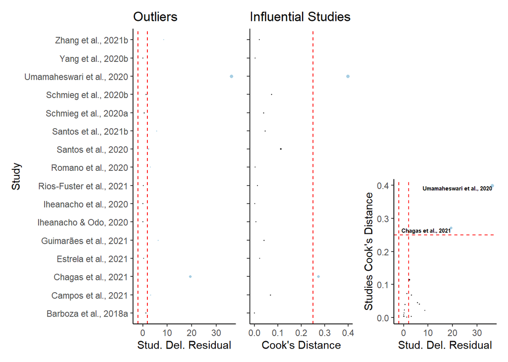

```r
influentialcases_plots(mRE, "ML_RobVar", "ML", 3)
```

# Multilevel meta-regression

SYRCLE PROTOCOL: Meta-regression will be used for outcomes with at least 10 experiments.

> The minimal number of studies or effect sizes required by a multilevel meta-regression remains unknown, albeit some simulation studies suggest that the estimates of model coefficients of a multilevel meta-regression are generally stable under various simulated situations.(Yang et al. 2023) … the complexity of parameterization of such a meta-regression requires a large dataset to make optimization algorithms free of convergence issues.(Yang et al. 2023)

## Model 1: Size, Duration, Development

```r
df_MR <- select(df, c("Year", "StudyID", "Study", "EScluster", "ESid", "DevelopmentalStage",
    "ExposureDurationDays", "ParticleSizeMean", "yi", "vi"))

mname1 <- "Base"
mname2 <- paste0(mname1, "_RobVar")

mods_formula <- formula(~ParticleSizeMean + ExposureDurationDays * DevelopmentalStage)

mMR[[mname1]] <- rma.mv(yi, VCV, random = RE_formula, mods = mods_formula, data = df_MR,
    slab = Study, method = "REML", test = "t", dfs = "contain", level = 95)  #it will only keep complete cases

nSt_MR <- mMR[[mname1]]$s.nlevels[1]  # number of studies
nEC_MR <- mMR[[mname1]]$s.nlevels[2]  # number of ESclusters
nES_MR <- mMR[[mname1]]$s.nlevels[3]  # number of independent ES

print(paste0("Number of studies: ", nSt_MR, ", number of ES clusters: ", nEC_MR,
    " and number of independent observations of ES: ", nES_MR))
```

```
[1] "Number of studies: 15, number of ES clusters: 24 and number of independent observations of ES: 46"
```

```r
mMR[[mname2]] <- robust(mMR[[mname1]], cluster = df_MR$Study, clubSandwich = TRUE,
    verbose = TRUE)
mMR[[mname2]] <- additional_results(mMR[[mname2]])
```

The meta-regression comprised 46 comparisons from 24 control group clusters of 15 independent studies.

#### Diagnostics plots

```
Multivariate Meta-Analysis Model (k = 46; method: REML)

  logLik  Deviance       AIC       BIC      AICc
-54.3816  108.7632  130.7632  148.7767  140.9171

Variance Components:

            estim    sqrt  nlvls  fixed                factor
sigma^2.1  0.3332  0.5772     15     no                 Study
sigma^2.2  0.0000  0.0000     24     no       Study/EScluster
sigma^2.3  0.0539  0.2321     46     no  Study/EScluster/ESid

Test for Residual Heterogeneity:
QE(df = 38) = 86.5329, p-val < .0001

Number of estimates:   46
Number of clusters:    15
Estimates per cluster: 0-10 (mean: 0.78, median: 0)

Test of Moderators (coefficients 2:8):¹
F(df1 = 7, df2 = 0) = 0.0000, p-val = NA

Model Results:

                                                 estimate      se¹     tval¹
intrcpt                                           -2.3176  1.9488   -1.1892
ParticleSizeMean                                  -0.0040  0.0012   -3.3040
ExposureDurationDays                               0.1947  0.0789    2.4672
DevelopmentalStageLarva                            2.0485  1.9630    1.0436
DevelopmentalStageJuvenile                         3.7444  1.9773    1.8937
DevelopmentalStageAdult                            2.0675  1.7634    1.1724
ExposureDurationDays:DevelopmentalStageLarva      -0.1920  0.0789   -2.4329
ExposureDurationDays:DevelopmentalStageJuvenile   -0.2038  0.0794   -2.5665
                                                   df¹    pval¹    ci.lb¹
intrcpt                                          2.56   0.3330   -9.1756
ParticleSizeMean                                 1.34   0.1343   -0.0127
ExposureDurationDays                             1.61   0.1622   -0.2380
DevelopmentalStageLarva                          3.35   0.3661   -3.8476
DevelopmentalStageJuvenile                       3.23   0.1480   -2.3004
DevelopmentalStageAdult                           2.2   0.3522   -4.8882
ExposureDurationDays:DevelopmentalStageLarva     1.63   0.1631   -0.6168
ExposureDurationDays:DevelopmentalStageJuvenile  2.54   0.0978   -0.4846
                                                  ci.ub¹
intrcpt                                          4.5404
ParticleSizeMean                                 0.0046
ExposureDurationDays                             0.6273
DevelopmentalStageLarva                          7.9446
DevelopmentalStageJuvenile                       9.7892
DevelopmentalStageAdult                          9.0232
ExposureDurationDays:DevelopmentalStageLarva     0.2329
ExposureDurationDays:DevelopmentalStageJuvenile  0.0769   .

---
Signif. codes:  0 '***' 0.001 '**' 0.01 '*' 0.05 '.' 0.1 ' ' 1

1) results based on cluster-robust inference (var-cov estimator: CR2,
   approx t/F-tests and confidence intervals, df: Satterthwaite approx)
```

|  | ML | REML |
| --- | --- | --- |
| ll | -62.93917 | -54.38162 |
| dev | 85.71684 | 108.76324 |
| AIC | 147.87835 | 130.76324 |
| BIC | 167.99340 | 148.77668 |
| AICc | 155.64305 | 140.91708 |

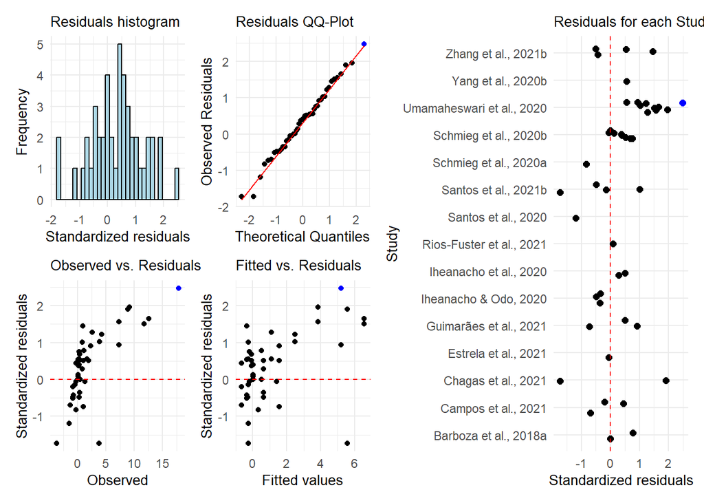

#### Influential cases

```
    Barboza et al., 2018a       Campos et al., 2021       Chagas et al., 2021
               0.43887676                0.05327593                5.54938408
     Estrela et al., 2021    Guimarães et al., 2021     Iheanacho & Odo, 2020
              25.09063580                        NA                1.16993321
   Iheanacho et al., 2020  Rios-Fuster et al., 2021       Santos et al., 2020
               0.84507433                7.06463995                0.85528885
     Santos et al., 2021b     Schmieg et al., 2020a     Schmieg et al., 2020b
               0.03748172                2.04830378              538.73247346
Umamaheswari et al., 2020        Yang et al., 2020b       Zhang et al., 2021b
               1.52235931                0.17357469                0.10226867
```

[figure not shown]

#### Orchard plots

(Nakagawa et al. 2021)

## Model 2: + Concentration

```
[1] "Number of studies: 10, number of ES clusters: 17 and number of independent observations of ES: 31"
```

The meta-regression comprised 31 comparisons from 17 control group clusters of 10 independent studies.

#### Diagnostics plots

```
Multivariate Meta-Analysis Model (k = 31; method: REML)

  logLik  Deviance       AIC       BIC      AICc
-44.7355   89.4711  111.4711  123.9615  135.4711

Variance Components:

            estim    sqrt  nlvls  fixed                factor
sigma^2.1  0.3655  0.6046     10     no                 Study
sigma^2.2  0.0000  0.0001     17     no       Study/EScluster
sigma^2.3  0.8318  0.9120     31     no  Study/EScluster/ESid

Test for Residual Heterogeneity:
QE(df = 23) = 62.9398, p-val < .0001

Number of estimates:   31
Number of clusters:    10
Estimates per cluster: 0-10 (mean: 0.53, median: 0)

Test of Moderators (coefficients 2:8):¹
F(df1 = 7, df2 = 0) = 0.0000, p-val = NA

Model Results:

                                              estimate      se¹     tval¹
intrcpt                                        -2.6225  1.7069   -1.5364
ParticleSizeMean                               -0.0067  0.0140   -0.4770
Concentration_mg_L                             -0.0003  0.0463   -0.0068
ExposureDurationDays                            0.2187  0.0783    2.7951
DevelopmentalStageLarva                         2.6575  2.2116    1.2016
DevelopmentalStageJuvenile                      3.3277  1.4816    2.2461
DevelopmentalStageAdult                         2.7898  1.4776    1.8880
ExposureDurationDays:DevelopmentalStageLarva   -0.2798  0.2106   -1.3289
                                                df¹    pval¹    ci.lb¹
intrcpt                                       2.23   0.2514   -9.2746
ParticleSizeMean                              1.99   0.6805   -0.0669
Concentration_mg_L                            1.23   0.9955   -0.3812
ExposureDurationDays                          1.76   0.1238   -0.1657
DevelopmentalStageLarva                       2.62   0.3268   -4.9937
DevelopmentalStageJuvenile                    2.35   0.1344   -2.2095
DevelopmentalStageAdult                       2.02   0.1981   -3.4947
ExposureDurationDays:DevelopmentalStageLarva  1.43   0.3572   -1.6413
                                                ci.ub¹
intrcpt                                        4.0296
ParticleSizeMean                               0.0536
Concentration_mg_L                             0.3805
ExposureDurationDays                           0.6032
DevelopmentalStageLarva                       10.3088
DevelopmentalStageJuvenile                     8.8649
DevelopmentalStageAdult                        9.0744
ExposureDurationDays:DevelopmentalStageLarva   1.0816

---
Signif. codes:  0 '***' 0.001 '**' 0.01 '*' 0.05 '.' 0.1 ' ' 1

1) results based on cluster-robust inference (var-cov estimator: CR2,
   approx t/F-tests and confidence intervals, df: Satterthwaite approx)
```

|  | ML | REML |
| --- | --- | --- |
| ll | -55.75567 | -44.73554 |
| dev | 58.90790 | 89.47109 |
| AIC | 133.51134 | 111.47109 |
| BIC | 149.28519 | 123.96153 |
| AICc | 147.40607 | 135.47109 |

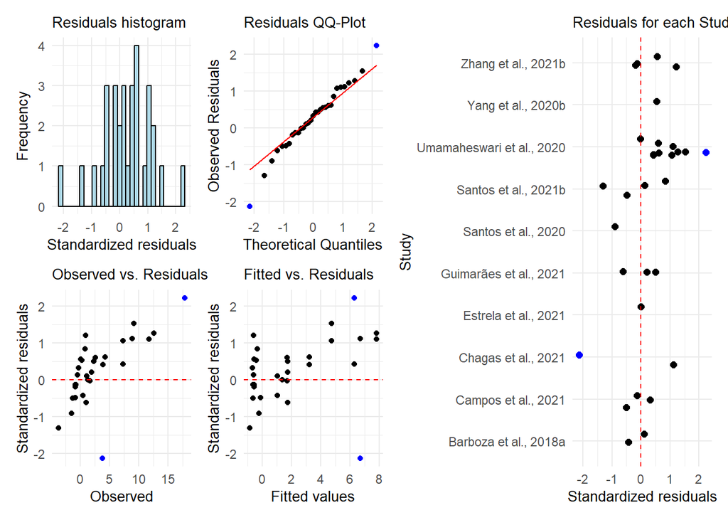

#### Influential cases

#### Orchard plots

## Model 3: + ParticleMaterial

```
[1] "Number of studies: 15, number of ES clusters: 24 and number of independent observations of ES: 46"
```

The meta-regression comprised 46 comparisons from 24 control group clusters of 15 independent studies.

#### Diagnostics plots

```
Multivariate Meta-Analysis Model (k = 46; method: REML)

  logLik  Deviance       AIC       BIC      AICc
-49.3194   98.6388  128.6388  151.5342  155.3055

Variance Components:

            estim    sqrt  nlvls  fixed                factor
sigma^2.1  0.7230  0.8503     15     no                 Study
sigma^2.2  0.0000  0.0000     24     no       Study/EScluster
sigma^2.3  0.0608  0.2465     46     no  Study/EScluster/ESid

Test for Residual Heterogeneity:
QE(df = 34) = 84.2348, p-val < .0001

Number of estimates:   46
Number of clusters:    15
Estimates per cluster: 0-10 (mean: 0.78, median: 0)

Test of Moderators (coefficients 2:12):¹
F(df1 = 11, df2 = 0) = 0.0000, p-val = NA

Model Results:

                                                 estimate      se¹     tval¹
intrcpt                                           -3.6106  2.7732   -1.3019
ParticleSizeMean                                  -0.0042  0.0060   -0.7000
ExposureDurationDays                               0.2264  0.0973    2.3268
DevelopmentalStageLarva                            3.2120  2.7314    1.1760
DevelopmentalStageJuvenile                         4.3518  2.6409    1.6479
DevelopmentalStageAdult                            2.7578  2.3312    1.1830
ParticleMaterialLDPE                               0.2480  1.4004    0.1771
ParticleMaterialPLA                               -0.6036  2.1143   -0.2855
ParticleMaterialPS                                 0.6646  0.7694    0.8638
ParticleMaterialPVC                               -0.2497  0.3789   -0.6589
ExposureDurationDays:DevelopmentalStageLarva      -0.2253  0.0977   -2.3056
ExposureDurationDays:DevelopmentalStageJuvenile   -0.2153  0.0976   -2.2058
                                                   df¹    pval¹     ci.lb¹
intrcpt                                          3.59   0.2701   -11.6661
ParticleSizeMean                                 1.57   0.5732    -0.0383
```

[output cut: 14 more lines]

```
DevelopmentalStageLarva                          11.0308
DevelopmentalStageJuvenile                       12.3381
DevelopmentalStageAdult                          11.0478
ParticleMaterialLDPE                              6.8129
ParticleMaterialPLA                               7.8073
ParticleMaterialPS                                2.8458
ParticleMaterialPVC                               4.0668
ExposureDurationDays:DevelopmentalStageLarva      0.2928
ExposureDurationDays:DevelopmentalStageJuvenile   0.0860

---
Signif. codes:  0 '***' 0.001 '**' 0.01 '*' 0.05 '.' 0.1 ' ' 1

1) results based on cluster-robust inference (var-cov estimator: CR2,
   approx t/F-tests and confidence intervals, df: Satterthwaite approx)
```

|  | ML | REML |
| --- | --- | --- |
| ll | -64.20798 | -49.31941 |
| dev | 88.25447 | 98.63883 |
| AIC | 158.41597 | 128.63883 |
| BIC | 185.84559 | 151.53424 |
| AICc | 174.41597 | 155.30550 |

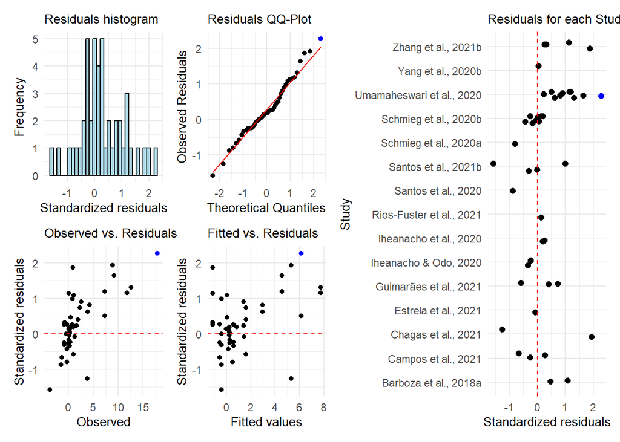

#### Influential cases

```
    Barboza et al., 2018a       Campos et al., 2021       Chagas et al., 2021
             2.278527e+00              1.222479e+01              1.162907e+01
     Estrela et al., 2021    Guimarães et al., 2021     Iheanacho & Odo, 2020
             7.279789e+01                        NA              2.006803e+00
   Iheanacho et al., 2020  Rios-Fuster et al., 2021       Santos et al., 2020
             5.314967e+02              2.344545e+01              1.130570e+00
     Santos et al., 2021b     Schmieg et al., 2020a     Schmieg et al., 2020b
             1.059607e-01              1.318425e+01              1.606267e+04
Umamaheswari et al., 2020        Yang et al., 2020b       Zhang et al., 2021b
             5.761280e+00              3.038366e-02              8.937021e+00
```

[figure not shown]

#### Orchard plots

# Referências

Harrer, Mathias, Pim Cuijpers, Toshi A. Furukawa, and David D. Ebert. n.d. *Chapter 9 Publication Bias | Doing Meta-Analysis in R*. https://bookdown.org/MathiasHarrer/Doing_Meta_Analysis_in_R/pub-bias.html.

Nakagawa, Shinichi, Malgorzata Lagisz, Michael D. Jennions, Julia Koricheva, Daniel W. A. Noble, Timothy H. Parker, Alfredo Sánchez-Tójar, Yefeng Yang, and Rose E. O’Dea. 2022. “Methods for Testing Publication Bias in Ecological and Evolutionary Meta-Analyses.” *Methods in Ecology and Evolution* 13 (1): 4–21. https://doi.org/10.1111/2041-210X.13724.

Nakagawa, Shinichi, Malgorzata Lagisz, Rose E. O’Dea, Joanna Rutkowska, Yefeng Yang, Daniel W. A. Noble, and Alistair M. Senior. 2021. “The Orchard Plot: Cultivating a Forest Plot for Use in Ecology, Evolution, and Beyond.” *Research Synthesis Methods* 12 (1): 4–12. https://doi.org/10.1002/jrsm.1424.

Stanley, T. D. 2017. “Limitations of PET-PEESE and Other Meta-Analysis Methods.” *Social Psychological and Personality Science* 8 (5): 581–91. https://doi.org/10.1177/1948550617693062.

Viechtbauer, Wolfgang. 2010. “Conducting Meta-Analyses in R with the Metafor Package.” *Journal of Statistical Software* 36 (August): 1–48. https://doi.org/10.18637/jss.v036.i03.

———. 2022. “Konstantopoulos (2011) [the Metafor Package].” https://www.metafor-project.org/doku.php/analyses:konstantopoulos2011.

Viechtbauer, Wolfgang, and Mike W.-L. Cheung. 2010. “Outlier and Influence Diagnostics for Meta-Analysis.” *Research Synthesis Methods* 1 (2): 112–25. https://doi.org/10.1002/jrsm.11.

Yang, Yefeng, Malcolm Macleod, Jinming Pan, Malgorzata Lagisz, and Shinichi Nakagawa. 2023. “Advanced Methods and Implementations for the Meta-Analyses of Animal Models: Current Practices and Future Recommendations.” *Neuroscience & Biobehavioral Reviews* 146 (March): 105016. https://doi.org/10.1016/j.neubiorev.2022.105016.